```python
# enable mypy type checking
try:
    %load_ext nb_mypy
except ModuleNotFoundError:
    print("Type checking facility (Nb Mypy) is not installed.")
    print("To use this facility, install Nb Mypy by executing (in a cell):")
    print("  !python3 -m pip install nb_mypy")
```

```
Version 1.0.3
```

# 2IS50 – Software Development for Engineers – 2022-2023

[figure not shown]

## Lecture 5.B (Sw. Eng.)

Lecturer: Lars van den Haak

### Review of Lecture 4.B

- Checking type hints
  - Extra type hint features
- Functional decomposition
  - Problem solving: Divide, Conquer & Rule
  - Single Responsibility Principle (SRP)
  - Jargon: *refactoring*
- `pytest` set-up and tear-down

### Preview of Lecture 5.B

- Using exceptions: EAFP versus LBYL
- Sphinx documentation
  - reStructuredText (reST, RST)
- Interface design
  - Application Programming Interface (API)
  - Command-Line Interface (CLI)
  - Graphical User Interface (GUI), `PyQt5`
- Data decomposition

```python
from collections import defaultdict, Counter
from typing import Tuple, List, Dict, Set, DefaultDict, Counter
from typing import Any, Sequence, Mapping, Iterable
from typing import Callable, Iterator, Generator
import math
import doctest
```

## Using Exceptions

Two sides:

- *Inside* function being called:
  - `raise` exception
  - to signal exceptional situation
  - when 'normal' response is not possible/appropriate
  - N.B. exception cannot be accidentally overlooked
- *Outside* function when calling it:
  - let execution abort, or
  - *catch* and *handle* exception

### Two Styles: LBYL and EAFP

- **Look Before You Leap** ([LBYL](https://docs.python.org/3/glossary.html#term-lbyl))
  - Check assumptions before call (with `if`)
  - Only call if assumptions hold
  - Avoid triggering of exceptions
- **Easier to Ask for Forgiveness than Permission** ([EAFP](https://docs.python.org/3/glossary.html#term-eafp))
  - Just make the call (with `try`)
  - knowing that you'll be 'forgiven', if assumptions don't hold
  - i.e., no hard disk wiped, but exception raised

See: [Python Glossary](https://docs.python.org/3/glossary.html)

### Intermezzo: [Grace Murray Hopper](https://en.wikipedia.org/wiki/Grace_Hopper)

[figure not shown]

- Rear Admiral *Grace Murray Hopper*: early programmer
- Introduced the term *bug* for computer/software defect
- ["It's easier to ask for forgiveness than it is to get permission"](https://en.wikiquote.org/wiki/Grace_Hopper)
  - "If it's a good idea, go ahead and do it.  
    It is much easier to apologize than it is to get permission."
- "Life was simple before World War II. After that, we had systems."
- [ACM Grace Murray Hopper Award](https://awards.acm.org/hopper)
  - given to the outstanding young computer professional of the year

    Image source: https://commons.wikimedia.org/wiki/Category:Grace_Hopper#/media/File:Grace_Hopper.jpg

### Two Examples

```python
# LBYL

x = -1.0  # float computed earlier

if x >= 0:  # Look
    print(math.sqrt(x))  # Leap
else:
    print("x is negative")
```

```
x is negative
```

```python
# EAFP

x = -1.0  # float computed ealier

try:
    print(math.sqrt(x))  # ask for forgiveness
except ValueError:
    print("x is invalid argument for math.sqrt()")
```

```
x is invalid argument for math.sqrt()
```

```python
# EAFP (better: less code in try)
from typing import Optional

x = -1.0  # float computed ealier
root: Optional[float]

try:
    root = math.sqrt(x)
except ValueError:
    root = None
    print("x is invalid argument for math.sqrt()")
else:
    print(root)
```

```
x is invalid argument for math.sqrt()
```

```python
# LBYL

user_input = input("Give me float x: ")

if isfloat(user_input):  # Look (not defined; hard)
    print(f"x squared is {float(user_input) ** 2}")  # Leap
else:
    print("x must be a float")
```

```
<cell>5: error: Name "isfloat" is not defined
```

[output not shown]

```python
# EAFP

user_input = input("Give me float x: ")
x: Optional[float]

try:
    x = float(user_input)  # Ask for forgiveness
except ValueError:
    x = None
    print("x must be a float")
else:
    print(f"x squared is {x ** 2}")
```

[output not shown]

Checking whether a string can be converted to `float`

- is hard (https://stackoverflow.com/questions/736043/checking-if-a-string-can-be-converted-to-float-in-python)

| Command to parse | Is it a float? | Comment |
| --- | --- | --- |
| `print(isfloat(""))` | `False` |  |
| `print(isfloat("1234567"))` | `True` |  |
| `print(isfloat("NaN"))` | `True` | nan is also float |
| `print(isfloat("NaNananana BATMAN"))` | `False` |  |
| `print(isfloat("123.456"))` | `True` |  |
| `print(isfloat("123.E4"))` | `True` |  |
| `print(isfloat(".1"))` | `True` |  |
| `print(isfloat("1,234"))` | `False` |  |
| `print(isfloat("NULL"))` | `False` | Case insensitive |
| `print(isfloat(",1"))` | `False` |  |
| `print(isfloat("123.EE4"))` | `False` |  |
| `print(isfloat("6.523537535629999e-07"))` | `True` |  |
| `print(isfloat("6e777777"))` | `True` | This is same as Inf |
| `print(isfloat("-iNF"))` | `True` |  |
| `print(isfloat("1.797693e+308"))` | `True` |  |
| `print(isfloat("infinity"))` | `True` |  |
| `print(isfloat("infinity and BEYOND"))` | `False` |  |
| `print(isfloat("12.34.56"))` | `False` | Two dots not allowed |
| `print(isfloat("#56"))` | `False` |  |
| `print(isfloat("56%"))` | `False` |  |
| `print(isfloat("0E0"))` | `True` |  |
| `print(isfloat("x86E0"))` | `False` |  |
| `print(isfloat("86-5"))` | `False` |  |
| `print(isfloat("True"))` | `False` | Boolean is not a float |
| `print(isfloat(True))` | `True` | Boolean is a float |
| `print(isfloat("+1e1^5"))` | `False` |  |
| `print(isfloat("+1e1"))` | `True` |  |
| `print(isfloat("+1e1.3"))` | `False` |  |
| `print(isfloat("+1.3P1"))` | `False` |  |
| `print(isfloat("-+1"))` | `False` |  |
| `print(isfloat("(1)"))` | `False` | Brackets not interpreted |

```python
def isfloat(s: str) -> bool:
    """Check whether string is convertible to float."""
    try:
        float(s)  # result discarded
        return True  # cannot raise ValueError
    except ValueError:
        return False
```

### Trade-offs between LBYL and EAFP

- Amount of code
- Ease of checking up front
  - `math.sqrt()`: simple
  - `float()`: hard
- Performance
  - if assumption usually satisfied, `try` is faster
  - otherwise, `if` faster
  - in case of doubt, measure

## [Sphinx](https://www.sphinx-doc.org/): Documentation Generator

- Originally developed to document Python
- Based on *Docutils*
- Uses [*reStructuredText*](http://docutils.sourceforge.net/rst.html) format
- File extension `*.rst`
- Advice: Imitate given examples (HA-0, HA-1)

### reStructuredText

- Text markup
  - Similar to *MarkDown* (used in Jupyter notebooks)
  - But not the same!
  - [reStructuredText Primer](https://docutils.sourceforge.io/docs/user/rst/quickstart.html)
- [Interpreted text roles](https://docutils.sourceforge.io/docs/ref/rst/roles.html)
- [Directives](https://docutils.sourceforge.io/docs/ref/rst/directives.html)

### reST versus MarkDown

- Cannot use `_` (underscore) for italic/bold
  - Must use `*italic*` and `**bold**`
- Cannot use `` `typewriter` ``
  - Must use `` ``typewriter`` `` or *code role*
- Cannot use  
  `` ```python ``  
  `code`  
  `` ``` ``
  - Must use *code directive*
- Cannot use `$math$` or `$$math$$`
  - Must use *math role* or *math directive*
- Bullet/enumerated list must be preceded by *empty line*

### reStructedText: Text roles

- For *inline* use
- Syntax

  ```
  ... :role:`interpreted text` ...
  ```

- `:code:`
- `:math:`
- Sphinx adds its own
  - `:const:`
  - `:data:`
  - `:func:`
  - `:class:`
  - `:attr:`
  - `:meth:`
- reStructuredText can be used in *docstrings*
- For functions, use the following *fields*:
  - `:param name: description`
  - `:return: description`
  - `:raise exc: description`
- Do *not* duplicate type information; *avoid*
  - `:type name: ...`
  - `:rtype: ...`

### Sphinx Example

```python
#: The encoding of the three choice options
OPTIONS = {0: "Rock", 1: "Paper", 2: "Scissors"}

#: The valid choice letters
RPS = "".join(name[0].lower() for name in OPTIONS.values())
```

```python
def rps_choice(letter: str) -> int:
    """Return choice integer corresponding to given letter.

    The letter is first converted to lower case.

    Assumptions:

    * ``len(letter) == 1``
    * ``letter.lower() in RPS``

    :param letter: letter to convert to integer
    :return: integer in :const:`OPTIONS` corresponding to ``letter``
    :raise AssertionError: if  ``letter`` is invalid

    :examples:

    >>> rps_choice('r')
    0
    >>> rps_choice('P')
    1
    >>> rps_choice('s')
    2
    >>> rps_choice('X')
    Traceback (most recent call last):
        ...
    AssertionError: letter.lower() must be in RPS
    """
    assert letter.lower() in RPS, "letter.lower() must be in RPS"

    return RPS.index(letter.lower())
```

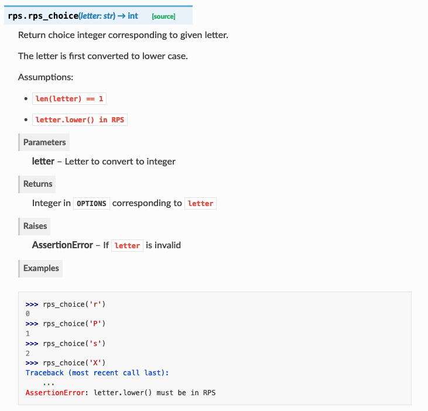

In [Python documentation](https://docs.python.org/):

- **Show Source**, in panel on the left
- E.g. [Built-in Functions](https://docs.python.org/3/library/functions.html): [Show Source](https://github.com/python/cpython/blob/3.8/Doc/library/functions.rst)

### reStructuredText: Directives

- For use on *blocks*
- Syntax:

  ```
  .. directive type:: argument
     :option: value
     :option: value

     content
  ```

- Block content consists of (multiple) indented lines

```
.. image:: picture.png
```

Can tweak options (see HA-1)

```
.. code:: python

   def hello():
       print("Hello")
```

- [Sphinx directives](https://www.sphinx-doc.org/en/master/usage/restructuredtext/directives.html)
- Sphinx Autodoc generates most of these from source code
- In project root directory, run (in Terminal):

```
$ sphinx-apidoc -f -o docs/source src tests
```

- Can include option `-n` (before `-o`) for *dry run*
  - Shows which files will be created
  - Does not create any files

### Advice on Documentation

- [Keep It Simple, Stupid](https://en.wikipedia.org/wiki/KISS_principle) (KISS)
- This is not the main goal of the course
- (But software documentation is too often forgotten)

## Interface Design

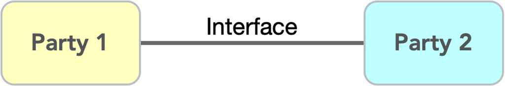

- Interface:
  - Sits between two parties
  - *Connects* and *separates*
  - Passes *control* and *data*
  - Control is usually *unidirectional*
  - Data can be *bidirectional*

### Types of interfaces in software

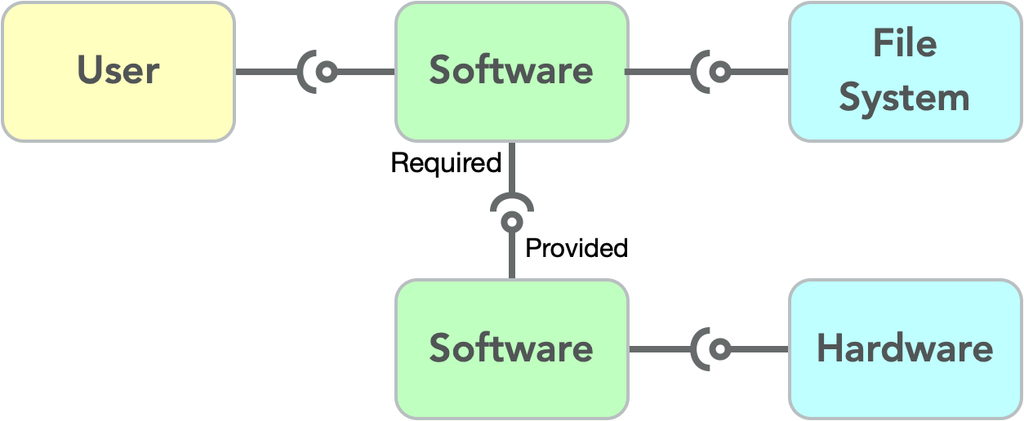

- File system, hardware
- Other software (API)
- Human users (CLI batch/text dialog, GUI)

### Application Programming Interface (API)

Program is like a Python *class* or *module*

- Program serves as *library* offering *services*:
  - constants
  - types (classes)
  - functions
- Environment *controls* the program
  - Can call functions in the program
  - Provide input data
  - Receive output data

### Command-Line Interface (CLI)

- User selects (some) inputs *before* starting program
  - *options*, *arguments*
- Batch mode
  - Programs produces output (on screen, in files)
  - Terminates when done
  - E.g. `sphinx-apidoc`
- Text dialog
  - Program interactively offers choices one by one
  - User responds
  - *Program controls the user*
  - E.g. `sphinx-quickstart`

In case you really want/have to go there:

- [How to Build Command Line Interfaces in Python with `argparse`](https://realpython.com/command-line-interfaces-python-argparse/)

### Graphical User Interface (GUI)

- *User controls the program*
  - A.k.a. *direct manipulation*
- User **generates events** (keyboard, mouse)
- In software
  - *main event loop* **dispatches events** (calls *event handlers*)
  - *event handler* **responds to events**

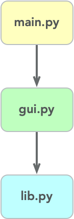

### Structure of program with GUI

- Initialization/set-up code
  - **front-end** / GUI
- Main event loop
- Underlying event handlers and utility code
  - **back-end** / business logic

*Control flow* is partly invisible, hidden in main event loop

### GUI with `PyQt5`

Qt5 is a professional C++ GUI library.

- PyQT5 is a binding to it
  - It has the exact same methods and attributes
  - uses Python equivalent types
- Qt is used by many programmers and companies.
  - E.g. LG, Mercedes-Benz

More details:

- [*DelftStack* Tutorial](https://www.delftstack.com/tutorial/pyqt5/)
- [Official Qt5 docs](https://doc.qt.io/qt-5/index.html) Very good & complete
- [Official PyQt5 docs](https://www.riverbankcomputing.com/static/Docs/PyQt5/) Unfortunately not so complete, better stick to the QT5 documentation!
- [PyQt5 Tutorial, Create GUI Applications with Python & Qt — Martin Fitzpatrick](https://www.mfitzp.com/courses/pyqt/)
- [PyQt5 YouTube Tutorial](https://www.youtube.com/watch?v=Vde5SH8e1OQ&list=PLzMcBGfZo4-lB8MZfHPLTEHO9zJDDLpYj)

### GUI Organization in `PyQt5`

- **[QWidgets](https://doc.qt.io/qt-5/qwidget.html)** (*Interactive objects*):
  - windows, buttons, text areas, frames, ...
  - *Hierarchical*: widgets can contain other widgets
- **Styles**:
  - Look and feel of all the widgets
- **Geometry managers**:
  - Exact placements or using layouts
- **Events handling**:
  - Event = function being called
- *Main event loop*

### QWidgets

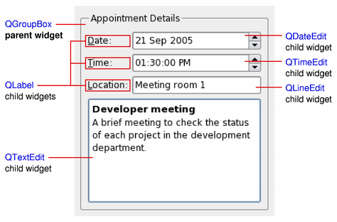

- **QMainWindow, QWidget**, (main) window or create new windows
- **QPushButton**, to click
- **QCheckBox, QRadioButton**, to select
- **QLineEdit, QTextEdit**, to enter data
- **QLabel**, to present short text
- **QPixmap**, for drawing
- **QGroupBox**, to group widgets
- **QMenuBar**, horizontal menubar
- **QDialog**, to show a message dialog

### Geometry Managers

- QLayout
  - Recommended: [QGridLayout](https://doc.qt.io/qt-5/qgridlayout.html)
- use `setGeometry()` (but keep track of resize Events yourself)

```python
import sys
from PyQt5 import QtGui, QtWidgets

app = QtWidgets.QApplication(sys.argv)
```

```python
class Window(QtWidgets.QWidget):
    def __init__(self) -> None:
        super().__init__()
        self.grid_layout = QtWidgets.QGridLayout()
        self.setLayout(self.grid_layout)

        for y in range(3):
            for x in range(2):
                label = QtWidgets.QPushButton(f"Button ({x}, {y})")
                self.grid_layout.addWidget(label, y, x)
        big_button = QtWidgets.QPushButton("Big Button")
        self.grid_layout.addWidget(big_button, 3, 0, 1, 2)


window = Window()
window.show()
result = app.exec_()
```

### Advice on GUI Design

- Start with a simple sketch
- Make a *mock-up* in PowerPoint
- Do group related elements in frames
- [Keep It Simple, Stupid](https://en.wikipedia.org/wiki/KISS_principle) (KISS)

### GUI Example (adapted from RealPython)

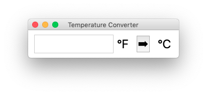

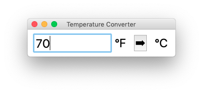

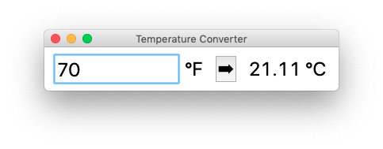

```python
# Back-end code (business logic)
# should not include GUI-related code


def fahrenheit_to_celsius(t: float) -> float:
    """Convert the value for Fahrenheit to Celsius."""
    celsius = (5 / 9) * (t - 32)
    return round(celsius, 2)
```

```python
# Front-end code (GUI)


class Window(QtWidgets.QMainWindow):
    def __init__(self) -> None:
        # Create root window
        super().__init__()
        main = QtWidgets.QWidget()
        layout = QtWidgets.QHBoxLayout()
        self.setCentralWidget(main)
        main.setLayout(layout)

        # increase font size for demo
        bigger_font = self.font()
        bigger_font.setPointSize(36)
        self.setFont(bigger_font)

        # Create widgets and relationships
        self.frm_entry = QtWidgets.QLineEdit("32")
        lbl_temp = QtWidgets.QLabel("\N{DEGREE FAHRENHEIT}")
        btn_convert = QtWidgets.QPushButton("\N{BLACK RIGHTWARDS ARROW}")
        self.lbl_result = QtWidgets.QLabel("       \N{DEGREE CELSIUS}")
        btn_convert.clicked.connect(self.set_temp)

        # Place widgets
        layout.addWidget(self.frm_entry)
        layout.addWidget(lbl_temp)
        layout.addWidget(btn_convert)
        layout.addWidget(self.lbl_result)

    def set_temp(self) -> None:
        temp_f = fahrenheit_to_celsius(float(self.frm_entry.text()))
        self.lbl_result.setText(f"{temp_f} \N{DEGREE CELSIUS}")


# Start main event loop
window = Window()
window.show()
result = app.exec_()
```

## Imperative Programming: The Big Picture

('imperative' = 'by giving commands')

- **Data**: *variables*

  Python: named & typed objects
- **Actions** on data: *statements* (commands)

  Python: `name = expr`, `if`, `while`, `function(...)`, `object.method(...)`

Statements can be *grouped* into a named, parameterized *function*

```
def function_name(parameters):
    statements
```

Variables can be *grouped* into a named, instantiable *class*,  
together with relevant operations (*methods*) on these variables

```
class Class_name:
    variables_and_methods
```

This grouping is also known as **encapsulation**.

### Functional decomposition

- Traditional view of computational problems: to define a (single) function.
- Client provides arguments (input), and function produces desired result (output).
- Instead of writing all statements of the solution in that single function,  
  break it up into smaller functions, whose *composition* solves the problem.

  You can also use predefined libary functions.
- **Decomposition** = breaking 'large' thing up into composition of 'smaller' things

Advantages of decomposition (*Divide & Conquer*):

- Easier to understand why it works
- Easier to get it to work
- Easier to document
- Easier to test
- Easier to reuse parts

### Data decomposition

Computational problems often concern *multiple* related operations on data.

- 'Modern' (OO) view on computational problems: to define a (single) class  
  holding all the data, and offering methods as operations (services).

  Think of an electronic calculator: each button corresponds to a method
- Client instantiates class, and repeatedly calls methods.
- Instead of writing all variables of the solution in that single class,  
  break it up into smaller classes, whose *composition* solves the problem.

  You can also use predefined library classes.

### GUI Library

- GUI library (like `PyQt5`) is example of data decomposition
- Lots of data involved in GUI
  - configuration details
  - state (what data did user enter)
- Data is distributed over separate classes (objects)

### OO Design: Nouns and verbs

- Consider the story behind your software
  - **nouns** relate to data
  - **verbs** relate to functions (actions)
- Functional decomposition:
  - decompose actions (data is secondary)
- Data decomposition:
  - decompose data (actions are secondary)
- **Top-down** view
  - initially consider problem as one whole
  - break it up into smaller pieces
- **Bottom-up** view
  - start with fragments
  - compose them into larger pieces

### Separation of Concerns

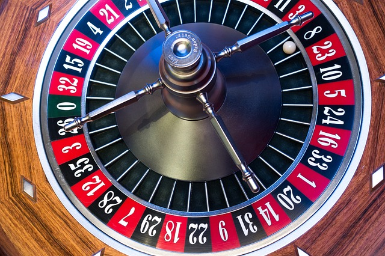

Source: [Building Skills in Object-Oriented Design](https://slott56.github.io/building-skills-oo-design-book/build/html/index.html) by Steven F. Lott

When [simulating Roulette](https://slott56.github.io/building-skills-oo-design-book/build/html/roulette/solution.html#preliminary-survey-of-classes), you encounter nouns:

- Wheel
- Bet
- Bin
- Table
- Red, Black, Green
- Number
- Odds
- Player
- House

Image source: https://pixabay.com/photos/roulette-roulette-wheel-ball-turn-1003120/

[Some roulette classes](https://slott56.github.io/building-skills-oo-design-book/build/html/roulette/solution.html#preliminary-roulette-class-structure):

- `Outcome`
- `Wheel`
- `Table`
- `Player`
- `Game`

**`Outcome`**

Responsibilities.

- A name for the bet and the payout odds.
- This isolates the calculation of the payout amount.
- Example: `“Red”, “1:1”`.

Collaborators.

- Collected by a `Wheel` object into the bins that reflect the bets that win;
- collected by a `Table` object into the available bets for the `Player`;
- used by a `Game` object to compute the amount won from the amount that was bet.

**`Wheel`**

Responsibilities.

- Selects the `Outcome` instances that win.
- This isolates the use of a random number generator to select `Outcome` instances.
- It encapsulates the set of winning `Outcome` instances that are associated with each individual number on the wheel.
- Example: the “1” bin has the following winning `Outcome` instances:
  - `“1”, “Red”, “Odd”, “Low”, “Column 1”, “Dozen 1-12”, “Split 1-2”, “Split 1-4”, “Street 1-2-3”, “Corner 1-2-4-5”, “Five Bet”, “Line 1-2-3-4-5-6”, “00-0-1-2-3”, “Dozen 1”, “Low” and “Column 1”`.

Collaborators.

- Collects the `Outcome` instances into bins;
- used by the overall `Game` to get a next set of winning `Outcome` instances.

**`Table`**

Responsibilities.

- A collection of bets placed on `Outcome` instances by a `Player`.
- This isolates the set of possible bets and the management of the amounts currently at risk on each bet.
- This also serves as the interface between the `Player` and the other elements of the game.

Collaborators.

- Collects the `Outcome` instances;
- used by `Player` to place a bet amount on a specific `Outcome`;
- used by `Game` to compute the amount won from the amount that was bet.

**`Player`**

Responsibilities.

- Places bets on `Outcome` instances,
- updates the stake with amounts won and lost.

Collaborators.

- Uses `Table` to place bets on `Outcome` instances;
- used by `Game` to record wins and losses.

**`Game`**

Responsibilities.

- Runs the game:
  - gets bets from `Player`,
  - spins `Wheel`,
  - collects losing bets,
  - pays winning bets.
- This encapsulates the basic sequence of play into a single class.

Collaborators.

- Uses `Wheel`, `Table`, `Outcome`, `Player`.
- The overall statistical analysis will
  - play a finite number of games and
  - collect the final value of the `Player`’s stake.

## (End of Notebook)

© 2019-2023 - **TU/e** - Eindhoven University of Technology - Tom Verhoeff